### Communicating the results

**Written.** As a minimum, the observed *t* statistic, the *p* value and the number of degrees of freedom should be reported. For example, you could write “The mean pollen count from the footprints (109 ) was significantly lower than expected if it was derived from the nearby forest with an average count of 125 (*t* = 3.07, df = 9, P = 0.01)”.

**Visual.** Box plots or frequency histograms can be used to visualise the variation in a single variable. In this example, you might use a line or arrow to indicate the single value (125) that you were comparing the sample to.

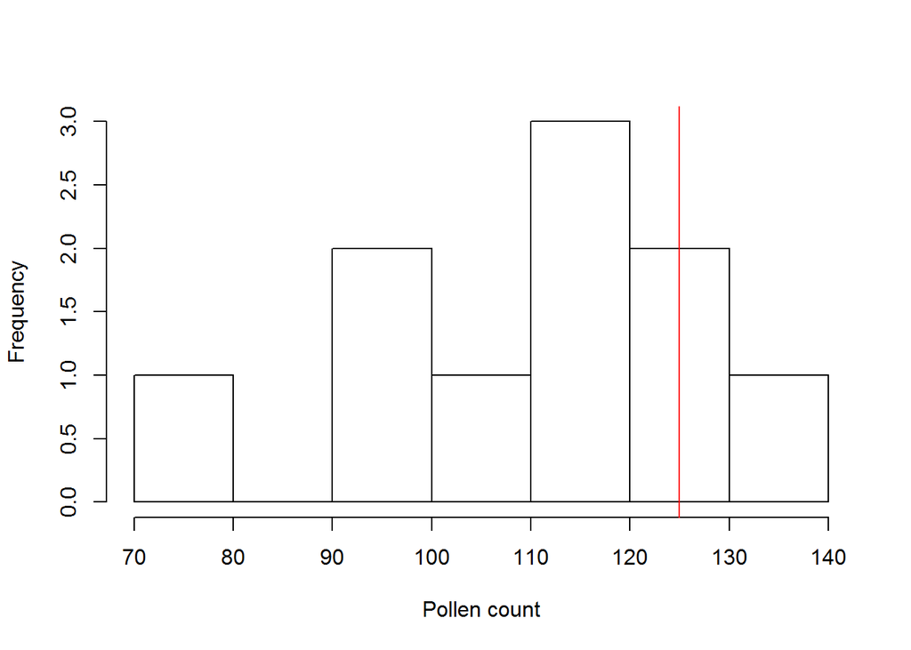

```r
hist(pollen, xlab = "Pollen count", main=NULL)
abline(v=125,col="red")
```

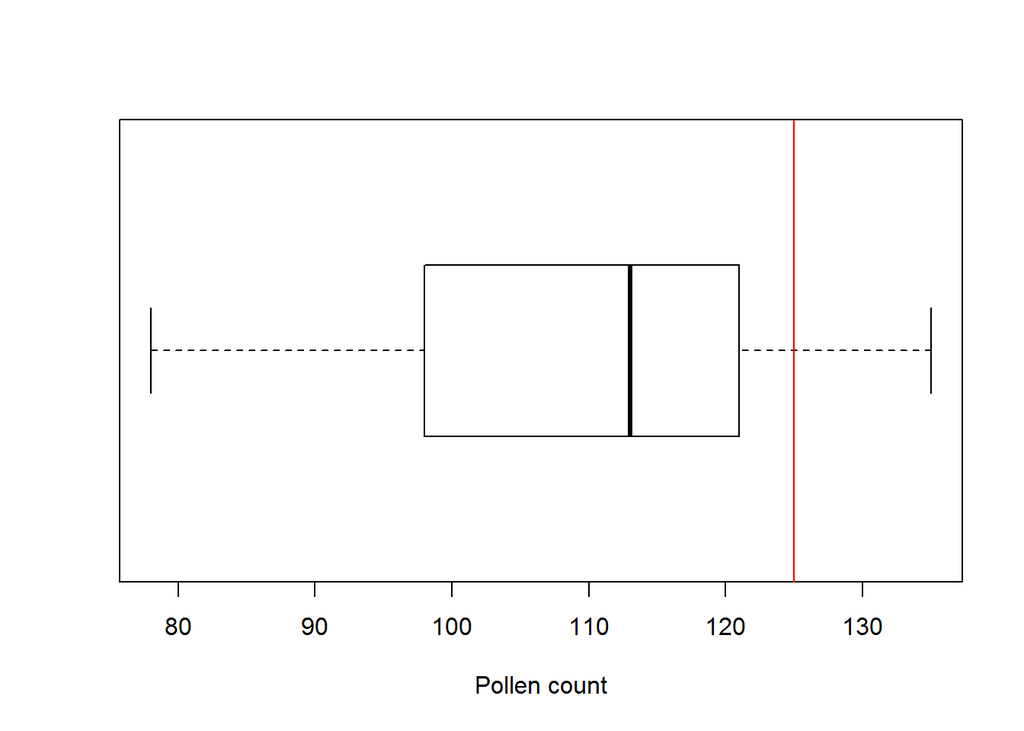

```r
boxplot(pollen,xlab = "Pollen count",horizontal =TRUE)
abline(v=125,col="red")
```

### Further help

Type `?t.test` to get the R help for this function.

Quinn and Keough (2002) *Experimental design and data analysis for biologists*. Cambridge University Press. Chapter 3: Hypothesis testing.

McKillup (2012) *Statistics explained. An introductory guide for life scientists.* Cambridge University Press. Chapter 9: Comparing the means of one and two samples of normally distributed data.

**Author**: Alistair Poore  
Last updated:

```
## [1] "Tue May 17 14:46:26 2016"
```